# Coronavirus v Čechách

# Základní statistiky

## Přehled

Základní přehled (testy)

| Datum | Přírustkový počet testů | Kumulativní počet testů | Pozitivita testů (v %) |
| --- | --- | --- | --- |
| 2020-10-22 | 46390 | 1977582 | 30.52 |
| 2020-10-23 | 45223 | 2022805 | 33.73 |
| 2020-10-24 | 39190 | 2061995 | 31.82 |
| 2020-10-25 | 21375 | 2083370 | 34.16 |
| 2020-10-26 | 34946 | 2118316 | 29.40 |

Základní přehled (nákaza)

| Datum | Přírustkový počet nakažených | Kumulativní počet nakažených | Kumulativní počet vyléčených | Kumulativní počet úmrtí |
| --- | --- | --- | --- | --- |
| 2020-10-23 | 15254 | 238325 | 110219 | 2063 |
| 2020-10-24 | 12471 | 250796 | 110641 | 2185 |
| 2020-10-25 | 7301 | 258097 | 110924 | 2310 |
| 2020-10-26 | 10273 | 268370 | 111301 | 2449 |
| 2020-10-27 | 15663 | 284033 | 111443 | 2547 |

Aktivní případy: `170043`

Aktuálně hospitalizovaní: `6191`

Podíl nakažených s těžkým průběhem: `3.64`%

Smrtnost: `0.9`%

## Testy

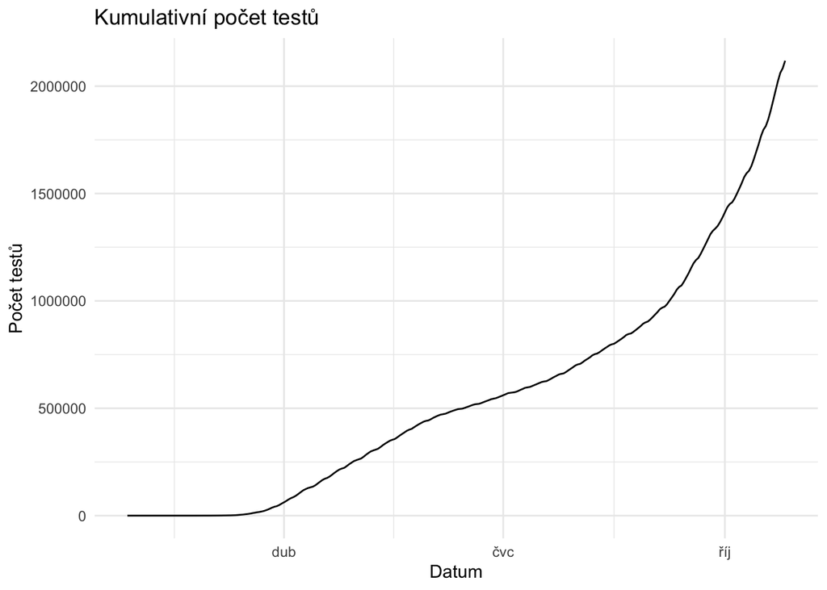

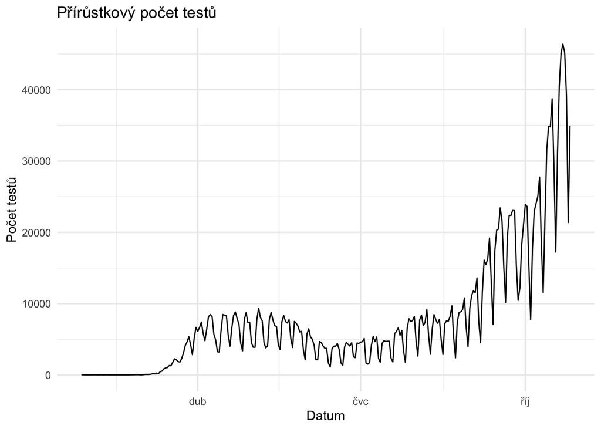

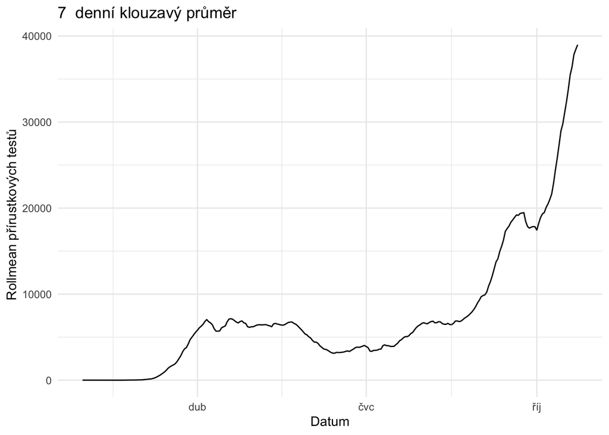

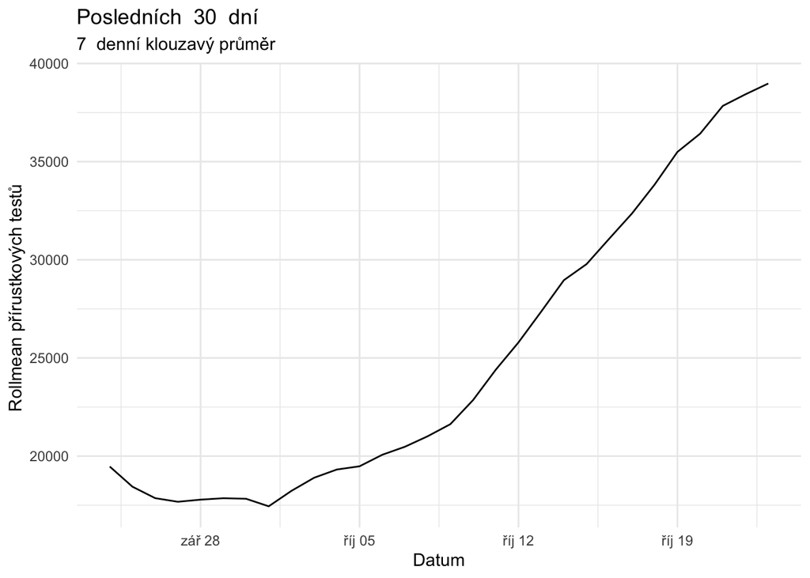

## Pozitivní případy

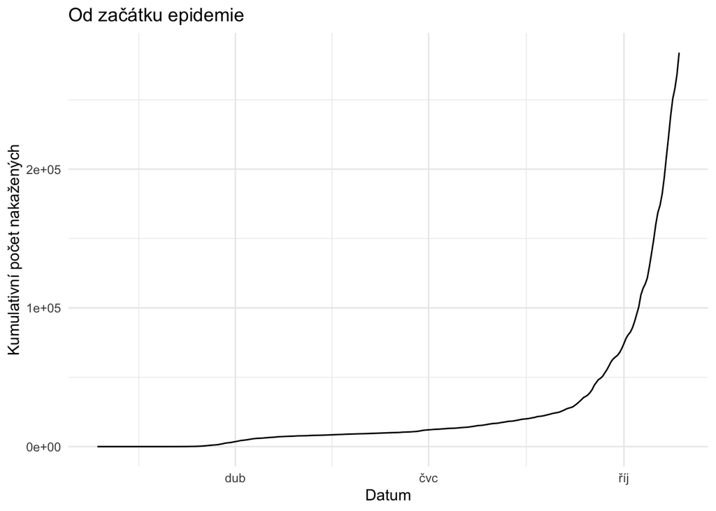

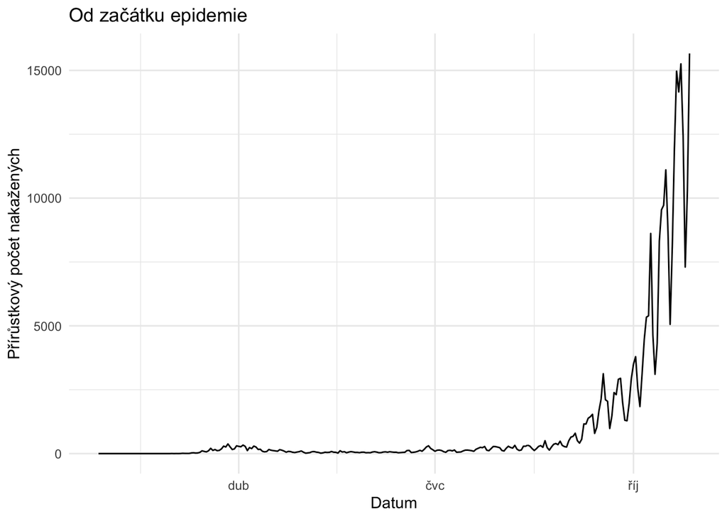

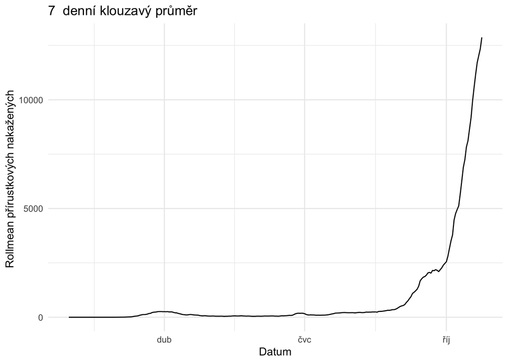

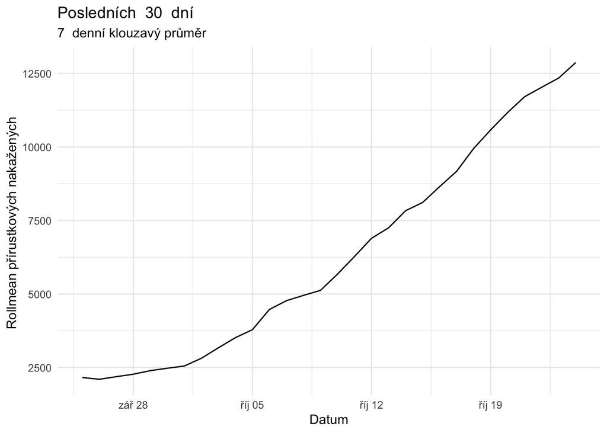

## Podíl pozitivních testů

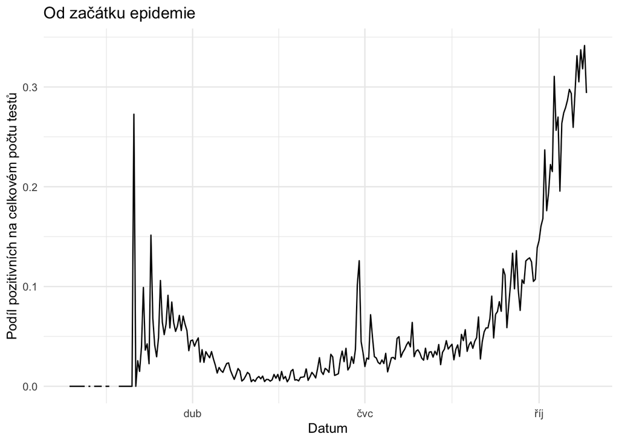

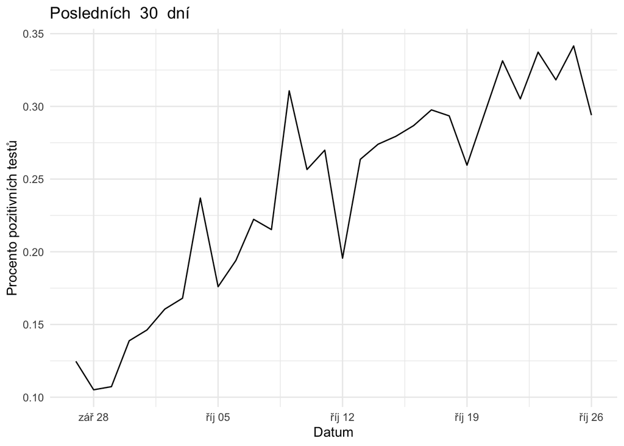

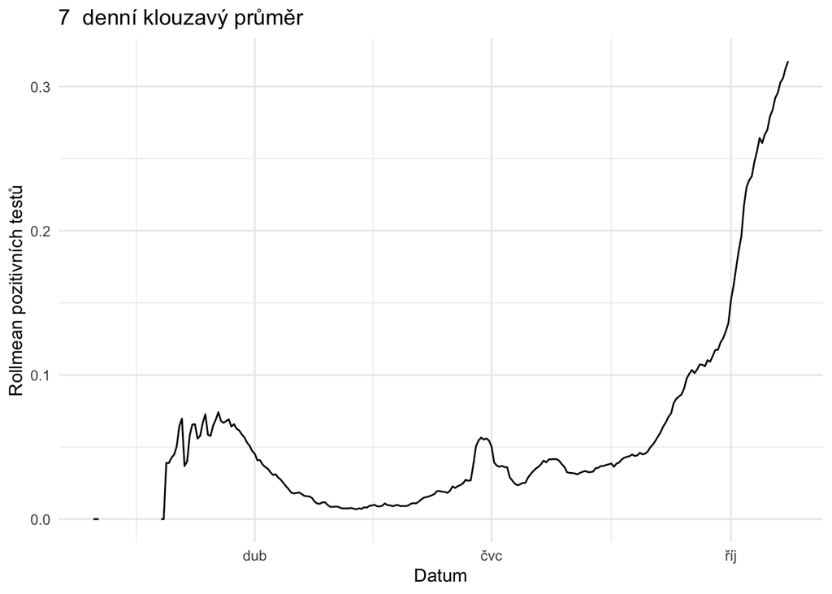

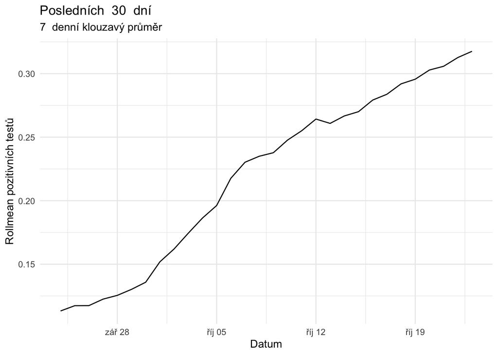

Podíl pozitivních testů na celkovém počtu od začátku epidemie je `13.408` %.

Podíl pozitivních testů na celkovém počtu za posledních 30 dní je `27.705` %.

# Modely

## Linearní model

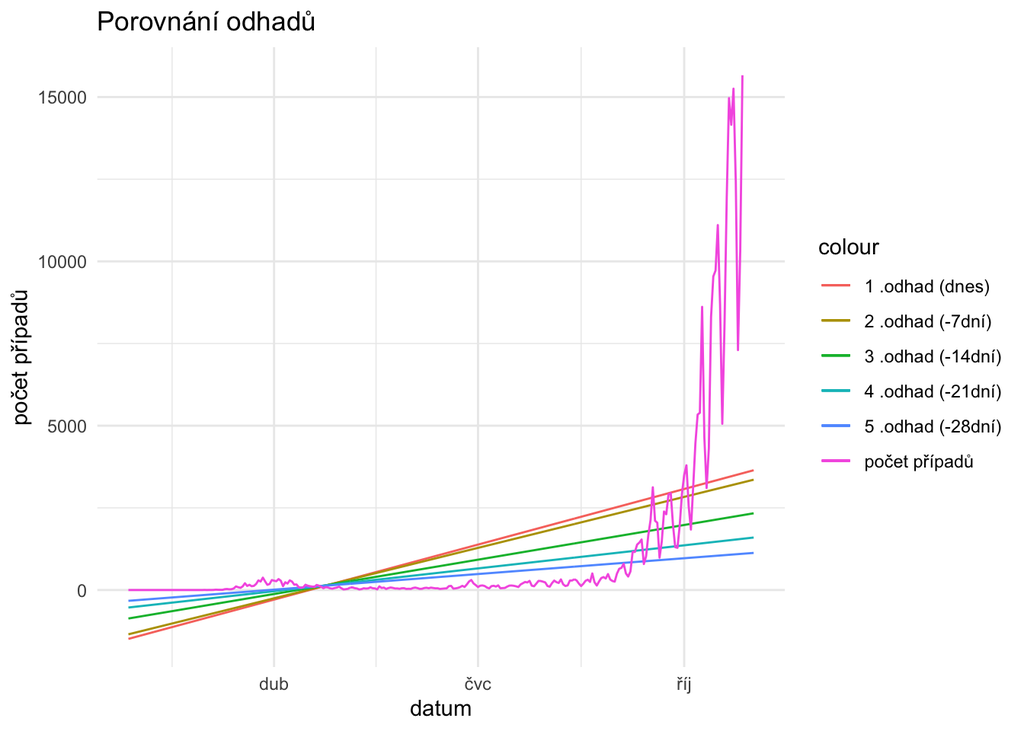

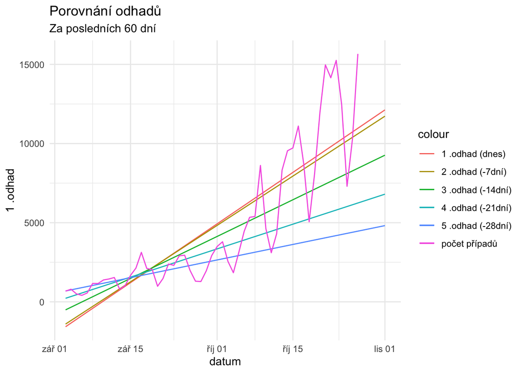

### Data (Lineární model)

#### Od začátku epidemie

Podle lineárního modelu bychom tímto tempem měli dne `2020-11-01` podle

- 1. odhadu `3644` nakažených denně
- 2. odhadu `3356` nakažených denně
- 3. odhadu `2335` nakažených denně
- 4. odhadu `1597` nakažených denně
- 5. odhadu `1129` nakažených denně

#### Za posledních `60` dní

Podle lineárního modelu bychom tímto tempem měli dne `2020-11-01` podle

- 1. odhadu `12125` nakažených denně
- 2. odhadu `11728` nakažených denně
- 3. odhadu `9265` nakažených denně
- 4. odhadu `6802` nakažených denně
- 5. odhadu `4815` nakažených denně

## Kvadratický model

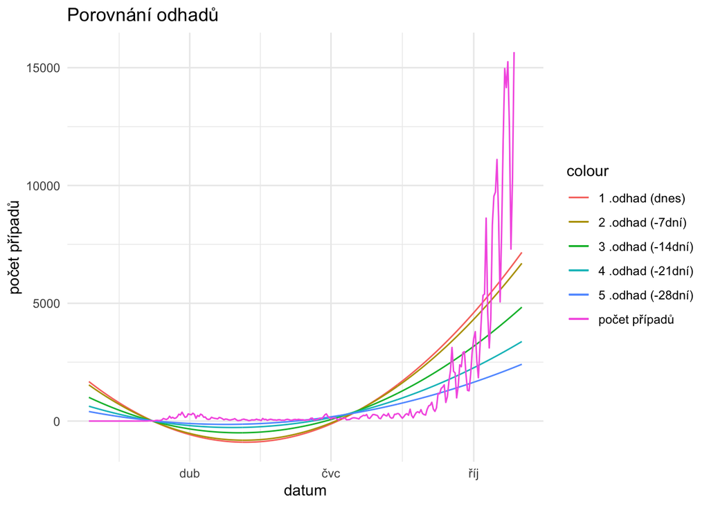

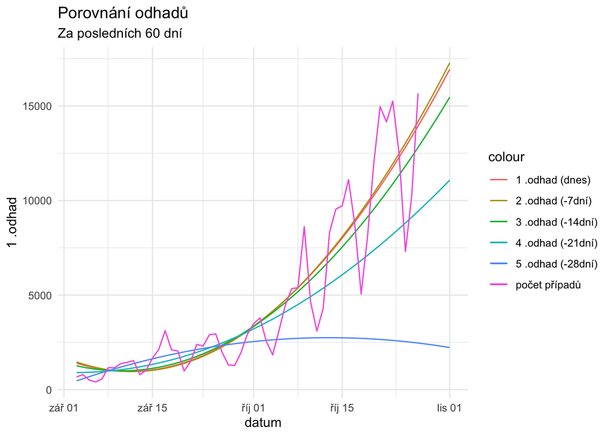

### Data (Kvadratický model)

#### Od začátku epidemie

Podle kvadratického modelu bychom tímto tempem měli dne `2020-11-01` podle

- 1. odhadu `7160` nakažených denně
- 2. odhadu `6696` nakažených denně
- 3. odhadu `4834` nakažených denně
- 4. odhadu `3376` nakažených denně
- 5. odhadu `2410` nakažených denně

#### Za posledních `60` dní

- 1. odhadu `16936` nakažených denně
- 2. odhadu `17272` nakažených denně
- 3. odhadu `15460` nakažených denně
- 4. odhadu `11077` nakažených denně
- 5. odhadu `2229` nakažených denně

## Exponential model

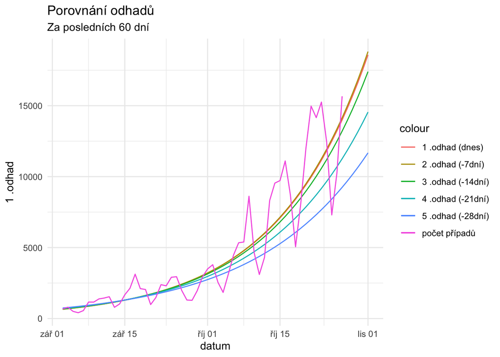

### Data (Exponential model)

#### Za posledních `60` dní

Podle exponencionálního modelu bychom tímto tempem měli dne `2020-11-01` podle

- 1. odhadu `18580` nakažených denně
- 2. odhadu `18812` nakažených denně
- 3. odhadu `17399` nakažených denně
- 4. odhadu `14549` nakažených denně
- 5. odhadu `11675` nakažených denně

Podle exponencionálního modelu bychom tímto tempem měli dnes dne `2020-10-28` podle

- 1. odhadu `14812` nakažených denně
- 2. odhadu `14979` nakažených denně
- 3. odhadu `13953` nakažených denně
- 4. odhadu `11851` nakažených denně
- 5. odhadu `9685` nakažených denně

# SIR MODELY

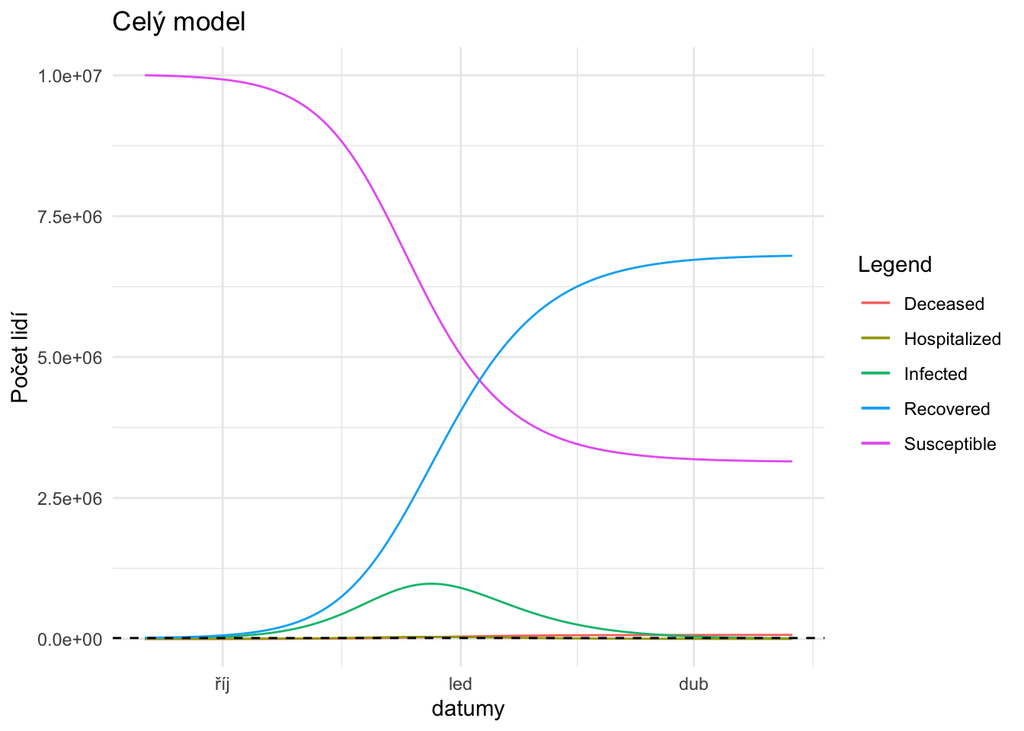

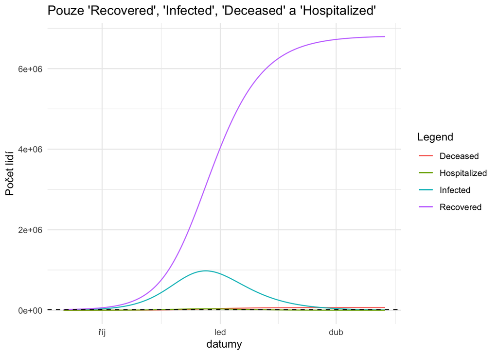

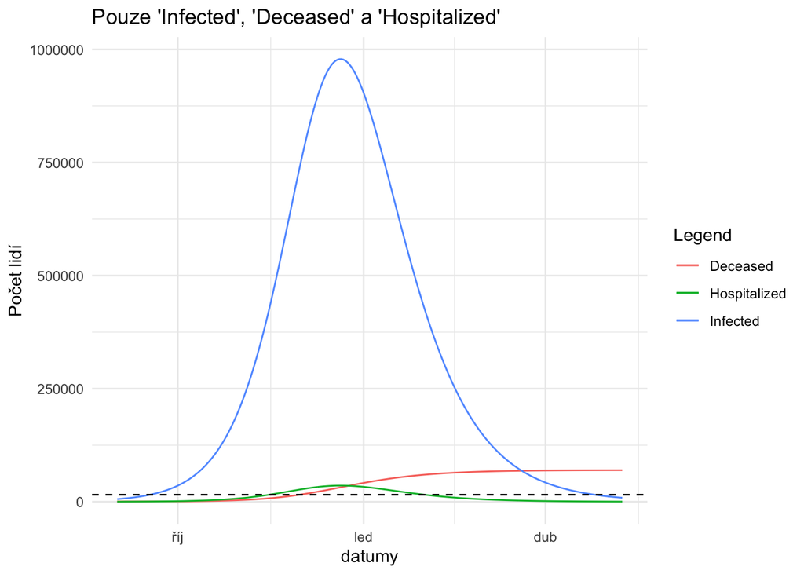

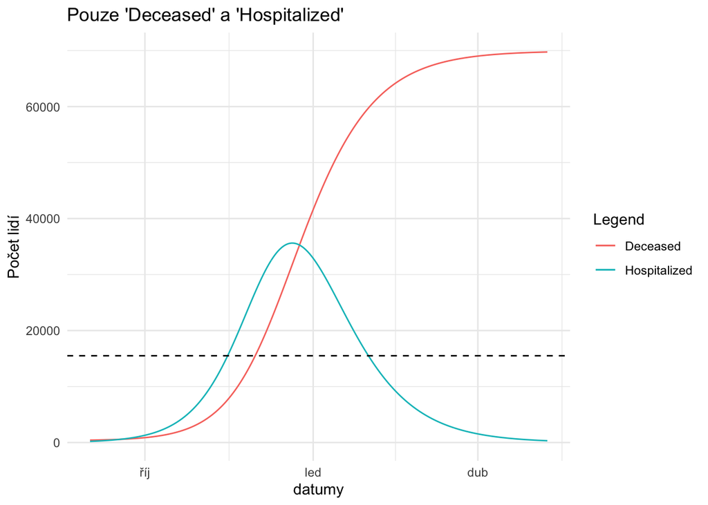

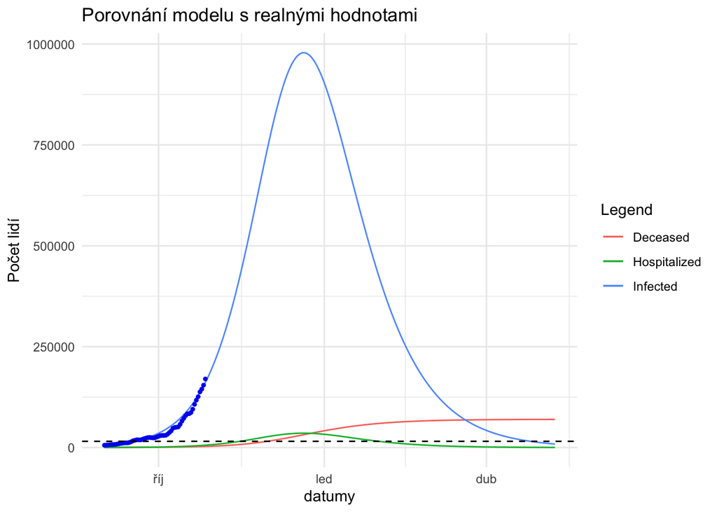

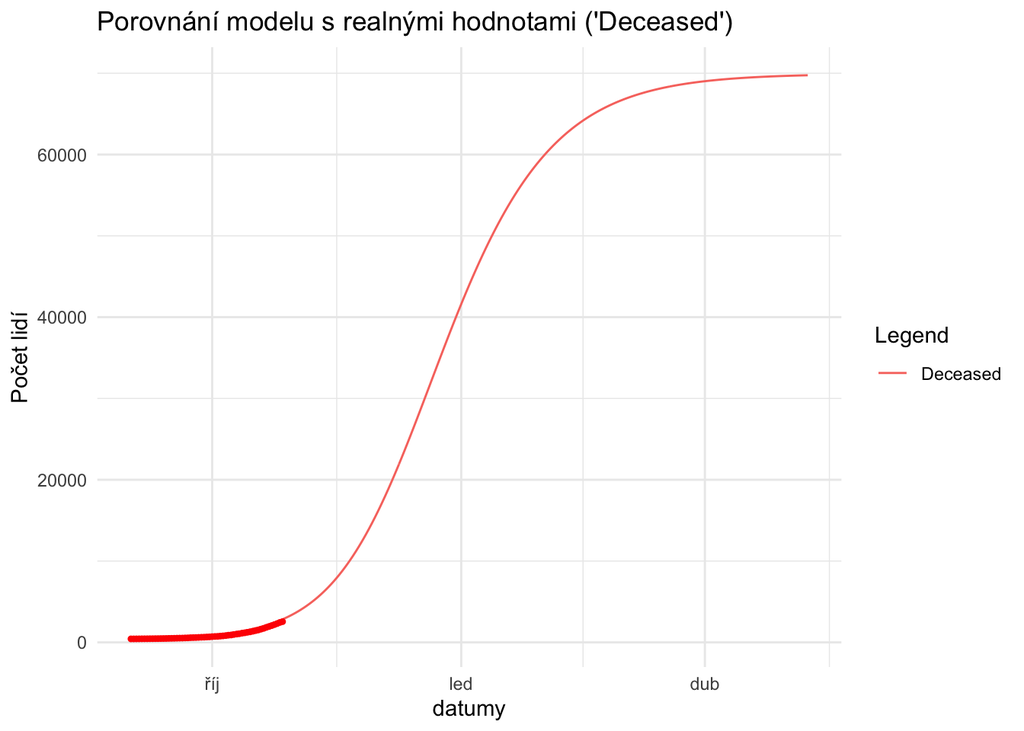

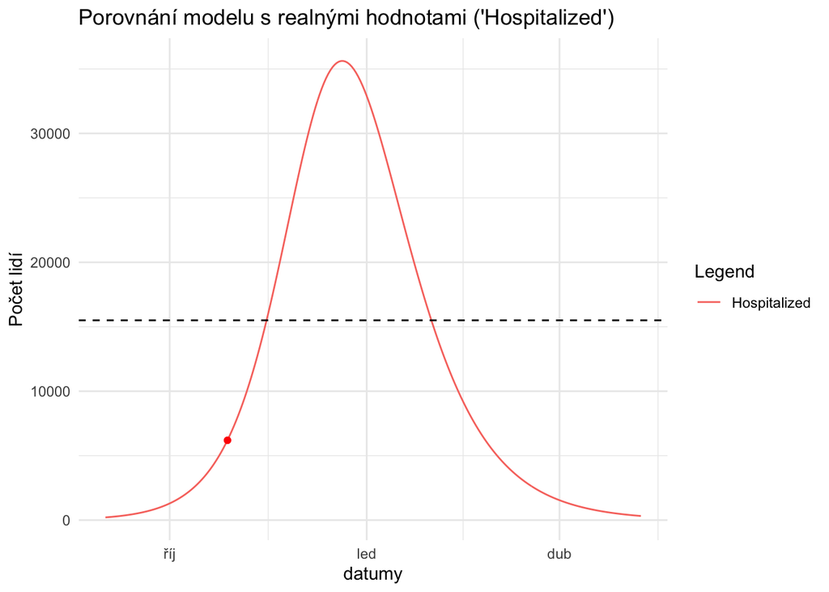

## Informace

`Peak nastane dne 2020-12-21 s počtem nakažených rovnu 978596 a aktuálním počtem hospitalizovných v nemocnicích 35621 lidí.`

`Kapacita nemocnic, která je stanovena na 15500 lůžek, bude při momentálním trendu překročena dne 2020-11-16`

`Celkově Covid-19 prodělá 6797261`

`Počet umrtí se zastaví na čísle 69752`

`Momentální hodnota rho je 1.705`

# Informace

Update proběhl `2020-10-28 12:49:32`.

Poslední data jsou z `2020-10-27` ze stránek ministerstva zdravotnictví ČR (https://onemocneni-aktualne.mzcr.cz/covid-19)